# Example Walkthrough

NYC Data Science Academy

*This is italic*

# Header 1

## Header 2

### Header 3

### Example Workflow of the shiny project

- Pick a dataset
- Save the dataset to a sqlite database
- Build user interface in ui.R
- Build server backend in server.R
  - Write query to extract the data from database according to user input
  - Use dplyr/tidyr to preprocess the data if needed
  - Use ggplot2/plotly/googleVis/leaflet to visualize your data

### R code chunks

```r
summary(cars)
```

```
##      speed           dist
##  Min.   : 4.0   Min.   :  2.00
##  1st Qu.:12.0   1st Qu.: 26.00
##  Median :15.0   Median : 36.00
##  Mean   :15.4   Mean   : 42.98
##  3rd Qu.:19.0   3rd Qu.: 56.00
##  Max.   :25.0   Max.   :120.00
```

```r
library(dplyr)
```

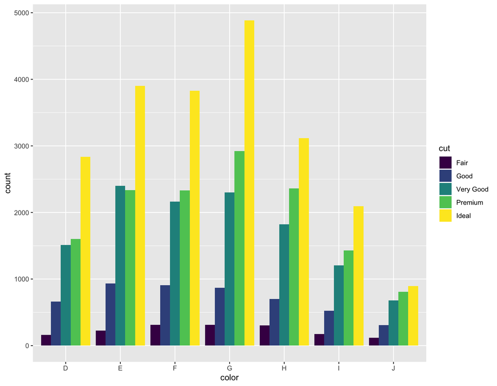

```r
library(ggplot2)

ggplot(data = diamonds, aes(x = color)) +

geom_bar(aes(fill = cut), position = "dodge")
```

### Introduction

- NYC’s Department of Health and Mental Hygiene (DOHMH) conducts unannounced inspections of restaurants at least once a year to check food handling, food temperature, personal hygiene, and vermin control. Since 2010, NYC restaurants have to prominently post their Grade (e.g. A/B/C) which empowers diners with decision-making information and incentivizes establishments to improve their hygiene.
- Download the csv file from [here](https://data.cityofnewyork.us/Health/DOHMH-New-York-City-Restaurant-Inspection-Results/43nn-pn8j) and rename it to `data.csv`. Move the file to the same directory of your markdown file and use relative path to read it.

### Load dataset

**You need to change eval=TRUE after you move the data.csv in the same directory**

```r
library(data.table)
raw.df <- fread("./data.csv", stringsAsFactors = F)
raw.df <- as.data.frame(raw.df)
str(raw.df)
```